# Ranking Content Pages for Refresh Review Using Search Performance Signals

Bhoomika Siddan

## Abstract

This study investigates whether historical search-performance signals can rank content pages for review before a near-term decline in impressions. Using the FlyRank internship warehouse, which contains approximately 78.8 million daily performance rows, I constructed an analytical cohort of 62,558 eligible client-page histories across 23 clients. A Random Forest using 13 February–April 2026 features was evaluated against a rule-based baseline, with May decline as the outcome and clients separated through five-fold grouped cross-validation. The grouped Random Forest measured 95% Precision@20, 75.62% average precision, and 75.31% ROC AUC, compared with 75%, 56.13%, and 59.71% for the baseline. These results support the model’s use as a human-reviewed prioritization tool, but they do not establish why a page declined or guarantee that refreshing it will improve performance.

## 1. Introduction and Problem Statement

Which content pages should an SEO or content team review first for a possible refresh, using only search-performance information available before the outcome period?

Specifically, this study examines whether a Random Forest using February–April 2026 signals—such as impressions, CTR, search position, recent change, and volatility—can rank pages likely to experience more than a 20% decline in impressions during May 2026 more effectively than the Week-4 rule baseline.

The intended decision is prioritization: helping a reviewer decide which pages to investigate first when review capacity is limited. A high model score indicates measured decline risk, not proof that a page needs to be refreshed. Declining impressions may also reflect changes in search demand, competition, seasonality, or technical conditions, so all recommended pages require human review.

## 2. Data

This study used the FlyRank internship warehouse release, build v20260703, hosted on Hugging Face. The full warehouse contains 78,835,655 daily performance rows covering January 27, 2025 through June 30, 2026. Each row in the primary source table, fact_content_daily_performance, represents one pseudonymized client’s content page on one report date.

The model analysis used the following windows:

February–April 2026 - Feature and observation period

April 30, 2026 - Prediction cutoff

May 2026 - Future outcome and validation period

Daily records were aggregated into monthly page-level summaries. The final development dataset contained 62,558 unique client-page histories across 23 clients, with no duplicate client-page rows. To improve data comparability, each page was required to have at least 20 days of available GSC data in February, March, April, and May. Pages were also required to have positive March and April impressions so that percentage-change calculations had valid denominators.

Only rows where gsc_data_available was true were included. The model used search-performance information such as impressions, clicks, CTR, average position, recent changes, and daily volatility. May performance was used only to define the outcome and was not supplied to the model as a feature.

Client and content identifiers were retained only for grouping, validation, and connecting recommendations back to pages; they were not model inputs. Product-generated flags and scores were excluded to avoid circular predictions. GA4 signals, raw search queries, client names, and page URLs were not used. Content metadata such as staleness and word count was also excluded from the final model because earlier audits found substantial missingness.

All identifiers in the analysis are pseudonymized. No private client names, URLs, access tokens, or raw queries are included in the notebook, figures, or exported recommendations.

## 3. Methodology

**Task and assumptions**

This study treats content decline as a binary classification and ranking problem. The model assigns each eligible page a risk score, which is used to rank pages for manual review.

The approach makes three main assumptions:

Recent search-performance patterns contain information about near-term impression decline.

Monthly measurements are sufficiently comparable when pages have at least 20 observed GSC days per month.

A future impression decline is a useful review signal, but it is not proof that a page needs refreshing or that a refresh will improve performance.

The analysis measures predictive associations rather than causal effects.

**Features**

All model features were available by the April 30, 2026 prediction cutoff. Thirteen features were organized into four groups:

| Feature group | Variables |
| --- | --- |
| Traffic level | February–April impressions, March impressions, and April impressions |
| Recent momentum | March-to-April impression percentage change |
| CTR | March CTR, April CTR, and CTR change |
| Search position | March average position, April average position, and position change |
| Stability | April impression variation, position variation, and proportion of observed days with impressions |

Impression totals were log-transformed to reduce the influence of extremely high-traffic pages. March-to-April percentage change was limited to between −100% and 500% so unusually large growth rates caused by small starting values would not dominate the model. Average search position was calculated by weighting position by impressions. Missing numerical values were replaced with the training-set median.

**Label definition**

The outcome was whether a page experienced more than a 20% decline in impressions from April to May 2026:

$$ \text{Future decline} = 1 \quad \text{if} \quad \text{May impressions} < 0.80 \times \text{April impressions} $$

Pages that did not cross this threshold received a label of zero. The label is a proxy for decline risk, not a direct measurement of content quality or refresh need. The outcome base rate among eligible pages was 48.79%.

**Week-4 baseline**

The reference baseline flagged a page when:

it received at least 300 impressions in March, and

its impressions declined by more than 20% from March to April.

Qualifying pages were ranked by their absolute impression loss from March to April. Pages that did not meet both conditions received a baseline score of zero. This represents a simple, understandable rule that the machine-learning model must improve upon.

**Model**

Logistic Regression was first examined as a simple and interpretable classifier. A Random Forest was selected as the final model because it can represent nonlinear relationships and interactions among traffic, CTR, search position, and volatility.

The Random Forest used 200 trees, a maximum depth of 10, a minimum of 25 observations per leaf, balanced class weighting within each tree sample, and a fixed random seed of 42. Its class-one output was used as a ranking score. The score should be interpreted as relative decline risk rather than a perfectly calibrated probability.

**Validation design**

An initial five-fold random row validation was used as a “before” design. However, it placed pages belonging to the same clients in both training and validation data, creating between 21 and 23 overlapping clients per fold.

The final evaluation used five-fold stratified client-grouped cross-validation. All pages belonging to one client were kept together, and every validation prediction came from a model that had not trained on that client. Client overlap was zero in all five folds. Every page received one out-of-fold risk score, allowing the model and baseline to be evaluated on the same 62,558 pages.

Precision@20 was the primary metric because the intended output is a small human-review queue. Precision@50, Precision@100, average precision, ROC AUC, and the outcome base rate were also reported.

May was used for label construction, threshold assessment, and model validation. Therefore, May is a development and validation period rather than an untouched final test period.

**Leakage checks**

The leakage audit confirmed that the 13 model features contained no May performance, outcome-derived columns, client or content identifiers, or FlyRank-generated flags and scores. It also checked for features that exactly copied the target, differences between training and validation columns, and client overlap between grouped folds.

No structural leakage was detected, and every grouped fold had zero client overlap. However, eligibility required at least 20 observed GSC days in May. May availability therefore influenced which pages were evaluated, even though May performance was not used as a model feature.

## 4. Results

The Week-4 baseline and Random Forest were evaluated on the same 62,558 eligible client-page histories. The Random Forest results below use client-grouped out-of-fold predictions, meaning each page was scored by a model that had not trained on pages from that client. The outcome base rate was 48.79%.

|  | Method | Base rate (%) | Precision@20 (%) | Precision@50 (%) | Precision@100 (%) | Average precision (%) | ROC AUC (%) |
| --- | --- | --- | --- | --- | --- | --- | --- |
| 0 | Week-4 baseline | 48.79 | 75.0 | 66.0 | 73.0 | 56.13 | 59.71 |
| 1 | Random Forest (client-grouped) | 48.79 | 95.0 | 96.0 | 98.0 | 75.62 | 75.31 |

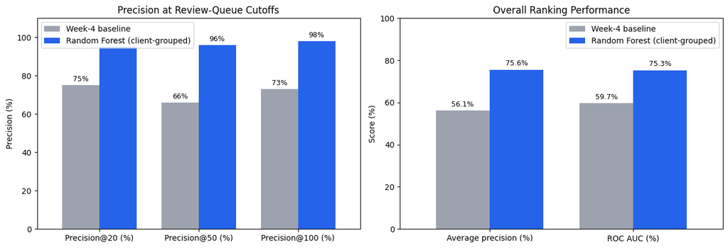

```
Figure saved to: work/figures/model_vs_baseline.png
```

**Interpretation**

The client-grouped Random Forest outperformed the Week-4 baseline on every reported aggregate metric. Among the top 20 pages, 19 experienced the defined May decline, compared with 15 of the baseline’s top 20. At 50 pages, the model correctly prioritized 48 declining pages compared with 33 for the baseline. At 100 pages, the corresponding counts were 98 and 73.

Average precision increased from 56.13% to 75.62%, an improvement of 19.49 percentage points. ROC AUC increased from 59.71% to 75.31%, an improvement of 15.60 percentage points. These results indicate that search position, CTR, traffic level, and volatility added useful ranking information beyond the baseline’s recent-impression-decline rule.

Random row validation produced average precision of 78.88% and ROC AUC of 78.62%. These values decreased to 75.62% and 75.31% under client-grouped validation, suggesting that random row validation provided a mildly optimistic estimate because clients overlapped between training and validation.

The grouped results provide evidence that the model can support review prioritization for eligible pages from the observed client population. However, the metrics are page-weighted, clients contributed very different numbers of pages, and performance was not equal across every client. The results do not establish that the model will perform equally on new time periods or that refreshing a selected page will recover impressions.

## 5. Limitations and Honest Framing

This analysis is observational and predictive rather than causal. A page receiving a high score does not prove that its content is outdated, that it caused the decline, or that refreshing it would recover impressions. The dataset does not contain post-refresh outcomes, so the project cannot measure whether recommended actions produce improvement.

May was used to define the outcome and assess the baseline and model. It is therefore a development and validation period, not an untouched final test period. June remained unused, so the reported results do not demonstrate performance on a later time window.

The evaluation included 23 clients with substantially different numbers of pages. Aggregate metrics are page-weighted and may be influenced more heavily by large clients, while performance was not equal across every client. Results should therefore not be assumed to generalize equally to all existing or future clients.

Eligibility also required at least 20 observed GSC days in May. Outcome availability influenced which pages entered the evaluation population, even though May performance was excluded from the model features. The findings apply most directly to pages with similar GSC coverage.

The model did not include direct measures of topic demand, competitor activity, algorithm changes, technical SEO problems, or content quality. Content age and word count were excluded because earlier audits found substantial missingness. Finally, the model output is used as a relative ranking score and should not be interpreted as a perfectly calibrated probability.

## 6. Ranked recommendations

The model ranked all 62,558 eligible pages by relative decline risk. Because manual review capacity is limited, the first recommended action is to review the top 20 pages. The ranking determines which pages should be examined first; it does not automatically determine that a page should be refreshed.

Each page receives one primary reason code based on an observable pre-May signal. The reason code makes the recommendation easier to investigate, but it should not be interpreted as a complete explanation of the model’s score or the cause of decline.

Within the top-20 review batch, 19 pages showed a March-to-April impression decline greater than 20%. One page had unusually volatile daily impressions despite increasing from March to April. The second case is especially important: a high model score can indicate instability even when the most recent monthly total increased.

|  | Reason code | Pages in top 20 | Share of top 20 (%) | Suggested action |
| --- | --- | --- | --- | --- |
| 0 | recent_impression_decline | 19 | 95.0 | Review for possible refresh |
| 1 | high_impression_volatility | 1 | 5.0 | Diagnose traffic instability |

|  | Reason code | Suggested human action |
| --- | --- | --- |
| 0 | recent_impression_decline | Review content freshness, accuracy, and search... |
| 1 | high_impression_volatility | Investigate whether traffic changes are tempor... |
| 2 | worsening_search_position | Review search results, relevance, and competin... |
| 3 | high_position_volatility | Investigate inconsistent rankings before chang... |
| 4 | high_visibility_at_risk | Prioritize manual review because substantial v... |
| 5 | elevated_model_risk | Perform a broader manual investigation |

|  | Rank | Model risk score | Action | Reason |
| --- | --- | --- | --- | --- |
| 0 | 1 | 0.973374 | Review for possible refresh | April impressions were 47.7% lower than March |
| 1 | 2 | 0.973020 | Review for possible refresh | April impressions were 50.7% lower than March |
| 2 | 3 | 0.972297 | Review for possible refresh | April impressions were 41.1% lower than March |
| 3 | 4 | 0.971355 | Review for possible refresh | April impressions were 61.2% lower than March |
| 4 | 5 | 0.971314 | Review for possible refresh | April impressions were 39.2% lower than March |

**Recommended Review Process**

For each selected page, the reviewer should:

Confirm that the page is still published, indexable, and strategically valuable.

Verify that the decline is not caused by missing GSC data or a technical tracking problem.

Examine search demand, seasonality, ranking movement, competing results, and recent content changes.

Decide whether the appropriate response is a content refresh, technical correction, continued monitoring, or no action.

Record the decision and later outcome so future recommendations can be evaluated.

Recent impression decline is a useful prioritization signal, but it does not prove that content has decayed. Ranking changes may reflect competition or relevance, while impression volatility may reflect seasonality or unstable demand. The model therefore supports investigation rather than automatic action.

The full ranked queue is regenerated by w07_action_playbook.ipynb. Client and content identifiers are omitted from the public examples above, while the underlying notebook retains pseudonymized identifiers for reproducibility.

## 7. Reproducibility and Artifacts

The complete project is available in the Flyrankproject GitHub repository. The analysis was developed in Python using DuckDB, pandas, NumPy, scikit-learn, and Matplotlib. A fixed random seed of 42 was used for model fitting and validation.

The supporting notebooks are:

Data contract

Rule-based baseline

Model training and comparison

Validation and leakage audit

Action playbook

Capstone paper notebook

The notebooks query monthly Parquet partitions from the gated FlyRank internship warehouse using a user-provided Hugging Face read token. No access token or raw warehouse data is stored in the repository. The action-playbook notebook regenerates the complete ranked queue, while the committed figures and aggregate metrics JSON provide receipts for the paper’s reported results.

|  | Validation design | Average precision (%) | ROC AUC (%) |
| --- | --- | --- | --- |
| 0 | Random row | 78.88 | 78.62 |
| 1 | Client-grouped | 75.62 | 75.31 |

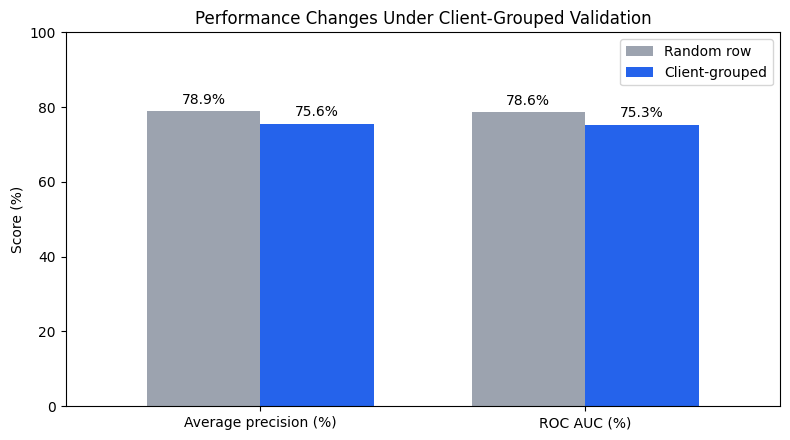

```
Figure saved to: work/figures/validation_design_comparison.png
```

**Validation-design takeaway:** Average precision decreased from 78.88% to 75.62%, and ROC AUC decreased from 78.62% to 75.31%, after pages were grouped by client. This suggests that random row validation produced a mildly optimistic estimate by allowing client overlap.

```
Metrics saved to: work/outputs/capstone_metrics.json
```

|  | Artifact | Path | Purpose | File exists |
| --- | --- | --- | --- | --- |
| 0 | Model vs. baseline charts | work/figures/model_vs_baseline.png | Show model improvement over the baseline | True |
| 1 | Validation-design chart | work/figures/validation_design_comparison.png | Show the effect of more honest validation | True |
| 2 | Aggregate metrics receipt | work/outputs/capstone_metrics.json | Record the paper's reported metrics | True |

```
PASS: All paper artifacts were generated.
```

## 8. Acknowledgments and Data Credit

I thank FlyRank for providing the internship curriculum, anonymized production search data, and project framework used to develop this analysis.

Built on the [FlyRank ML Internship dataset](https://flyrank.ai).

# ML-12 Communication Materials

Five-Minute Demo Outline

0:00–0:30 — The problem

Content teams cannot investigate every page. My project asks whether historical search-performance signals can rank pages for refresh review before a substantial near-term impression decline.

0:30–1:15 — Data and outcome

The source warehouse contains approximately 78.8 million daily performance rows. I constructed 62,558 eligible client-page histories across 23 clients, using February–April signals and defining the May outcome as an impression decline greater than 20%.

1:15–2:00 — Baseline

The Week-4 baseline selected pages with at least 300 March impressions and a March-to-April decline greater than 20%. It ranked qualifying pages by their absolute impression loss.

2:00–3:00 — Model and validation

I trained a Random Forest using 13 traffic, CTR, search-position, momentum, and volatility features. Five-fold client-grouped validation ensured that every page was evaluated by a model that had not trained on that client. The leakage audit found no May performance, target copies, identifiers, or product-generated flags among the model features.

3:00–4:00 — Results

The grouped Random Forest measured 95% Precision@20 compared with 75% for the baseline. Average precision increased from 56.13% to 75.62%, while ROC AUC increased from 59.71% to 75.31%.

4:00–4:40 — Recommendations

The model produces a ranked human-review queue with one primary reason code and suggested action per page. Reviewers must investigate content freshness, search demand, competition, seasonality, and technical conditions before acting.

4:40–5:00 — Limits and conclusion

The system predicts decline risk rather than refresh success. It is a retrospective decision-support prototype and should not automate rewriting, publishing, redirecting, or deleting content.

## Social-post cut

I built a content decline-risk ranking system using FlyRank’s production-scale search warehouse.

From approximately 78.8 million daily performance rows, I constructed 62,558 eligible client-page histories and trained a Random Forest using traffic, CTR, search-position, momentum, and volatility signals. Under client-grouped validation, the model achieved 95% Precision@20, compared with 75% for my rule-based baseline.

The final output is a ranked human-review queue with reason codes and suggested actions—not an automated refresh system. The project also includes grouped validation, leakage checks, error analysis, public-safe recommendations, and documented limitations.

## Three-sentence employer-facing summary

I developed a Random Forest ranking system using a production-scale search warehouse to prioritize content pages for human refresh review. Using 13 historical search-performance features and client-grouped cross-validation, the model achieved 95% Precision@20 and 75.62% average precision, compared with 75% and 56.13% for the rule-based baseline. I translated the validated output into a public-safe action queue with reason codes, leakage checks, monitoring guidance, and explicit limits on automated use.